# Survival Analysis of Corporal Punishment Bans

Andy Grogan-Kaylor

# Introduction

Corporal punishment is associated with a number of deleterious outcomes for children, including increases in behavior problems and mental health problems.

A number of countries have instituted country wide bans upon the use of corporal punishment with children.

Below, we employ a variety of empirical strategies to explore the institution of these bans.

# Get The Data

> NB It is important to have data with the *correct risk set* which includes *all countries*, not just *countries that eventually ban corporal punishment*.

# `stset` The Data

# Graphs

## Survival Function

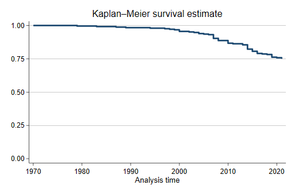

Kaplan-Meier Survivor Function

## Failure Function

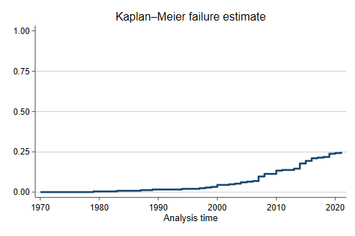

Kaplan-Meier Failure Function

# Survival Analysis

> Unlike other regression commands in Stata, survival analysis commands seem to require covariates.

## Data Wrangling

> Since Europe is where these bans started, we will use Europe (category 4) as the reference category.

## Cox Proportional Hazards Model

### Survival Curves

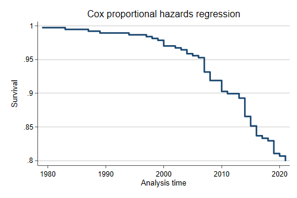

Survival Curve

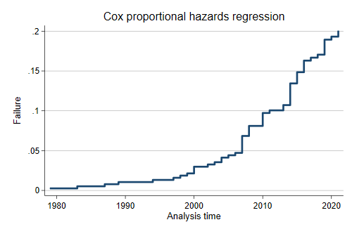

Failure Curve

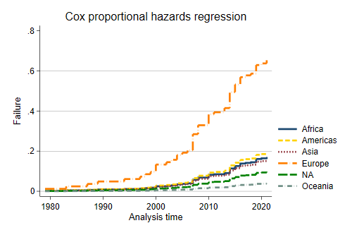

Failure Curve By Continent

### Proportional Hazards Assumption

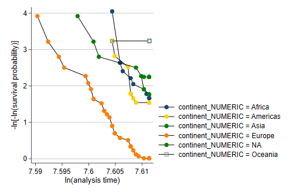

Graphical Test of Proportional Hazards Assumption

# Life Table

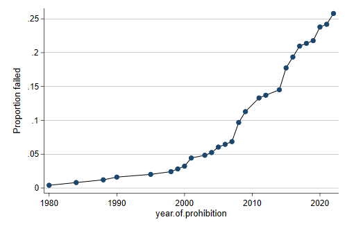

Graph Of Life Table

# Discrete Time Survival Analysis

Discrete time survival analysis is placed at the end because it requires us to restructure the data into a long format, where every row is a *country-year*.

## Restructuring the Data

We first need to generate a variable for the years during which a country was “at risk” of enacting a ban. Countries that have never enacted a ban are at risk up until the current year. Countries that enacted a ban leave the risk set once they have enacted a ban, and are thus at risk for a shorter time period.

We *expand* the data to generate one row of data for every year that each country is at risk.

We create a year variable.

Lastly, we generate an indicator of the event, a `0/1`’ variable, which takes the value 1 for rows in which a ban was enacted, and 0 otherwise.

# Analysis

# References

Allison, P. D. (1984). *Event History Analysis: Regression for Longitudinal Event Data*. SAGE Publications. Retrieved from https://books.google.com/books?id=XkACeUEiEsUC

Singer, J. D., & Willett, J. B. (2003). *Applied longitudinal data analysis : modeling change and event occurrence*. Oxford ; New York : Oxford University Press.

StataCorp. 2021. *Stata 17 Survival Analysis Reference Manual*. College Station, TX: Stata Press